# 25 - Class Notes

Fadel M Megahed

April 26, 2021

# 1 Recap of What we Learned this Past Week

1. Conduct tests for significance of individual regression coefficients.
2. Use a simple linear regression model for trend adjustment.
3. Interpret regression diagnostic plots.
4. Create prediction intervals for individual values of the response variable.
5. Discuss Exam 03 (Not in R).

## 1.1 Required Packages

In the code chunk below, we use the `pacman` package to load the required packages and install them if necessary.

```r
if(require(pacman)==FALSE) install.packages("pacman")
```

```r
pacman::p_load(tidyverse,
               magrittr, # for the two-way pipe
               fpp2, # accuracy() function, Arima(), auto.arima(),
               astsa, # package is for the required data
               plotly, # for interactive graphs
               stargazer)

source('https://raw.githubusercontent.com/fmegahed/businessForecasting/master/lectures/24%20-%20Time%20Series%20Regression%20(Cont)/resPlotTS.R') # loading our resPlot function from Last Class
```

## 1.2 An Overview of Exam 3

Please refer to our class discussions.

## 1.3 A Refresher of Time-Series Regression Concepts Learned so Far

Using the `jj` dataset from the [astsa package](https://cran.r-project.org/web/packages/astsa/astsa.pdf), we have discussed how we can regress the logged EPS for J&J as a function of time. The regression can be performed using the: (a) `lm()` from base R, where we would need to create the time-feature(s) ourselves, or (b) using the `tslm()` from the forecast package (which we typically load using fpp2). **In class, I will quickly go through the process of fitting the data to ensure that we are all on the same page.**

```r
log_jj = log(jj) # to make the data more linear and stablize the variance a bit
t = time(log_jj) # capture/create a time index


model1 = lm(log_jj ~ t)
summary(model1)
```

```
##
## Call:
## lm(formula = log_jj ~ t)
##
## Residuals:
##      Min       1Q   Median       3Q      Max
## -0.38309 -0.08569  0.00297  0.09984  0.38016
##
## Coefficients:
##               Estimate Std. Error t value Pr(>|t|)
## (Intercept) -3.275e+02  5.623e+00  -58.25   <2e-16 ***
## t            1.668e-01  2.854e-03   58.45   <2e-16 ***
## ---
## Signif. codes:  0 '***' 0.001 '**' 0.01 '*' 0.05 '.' 0.1 ' ' 1
##
## Residual standard error: 0.1585 on 82 degrees of freedom
## Multiple R-squared:  0.9766, Adjusted R-squared:  0.9763
## F-statistic:  3416 on 1 and 82 DF,  p-value: < 2.2e-16
```

```r
model2 = tslm(log_jj ~ trend)
summary(model2)
```

```
##
## Call:
## tslm(formula = log_jj ~ trend)
##
## Residuals:
##      Min       1Q   Median       3Q      Max
## -0.38309 -0.08569  0.00297  0.09984  0.38016
##
## Coefficients:
##               Estimate Std. Error t value Pr(>|t|)
## (Intercept) -0.6677756  0.0349073  -19.13   <2e-16 ***
## trend        0.0416992  0.0007134   58.45   <2e-16 ***
## ---
## Signif. codes:  0 '***' 0.001 '**' 0.01 '*' 0.05 '.' 0.1 ' ' 1
##
## Residual standard error: 0.1585 on 82 degrees of freedom
## Multiple R-squared:  0.9766, Adjusted R-squared:  0.9763
## F-statistic:  3416 on 1 and 82 DF,  p-value: < 2.2e-16
```

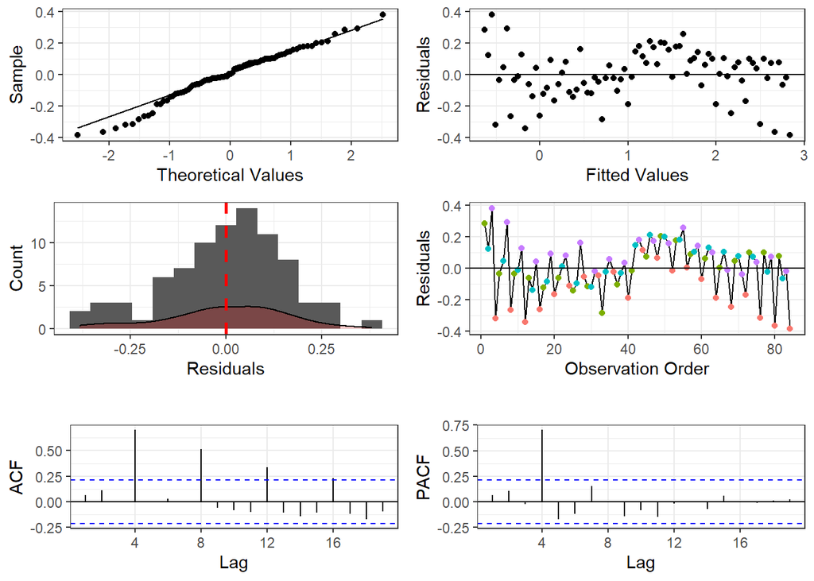

```r
resplot(res = model2$residuals, fit = model2$fitted.values, freq = 4)
```

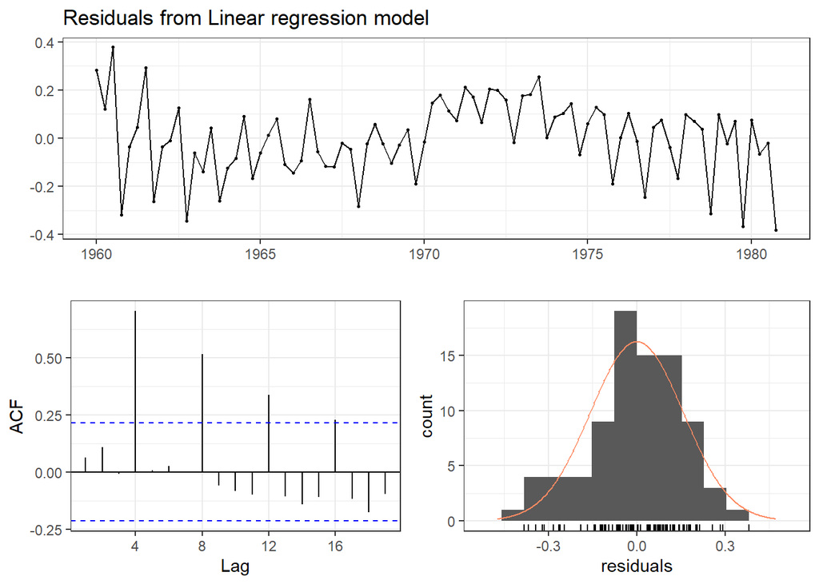

```
##
##  Breusch-Godfrey test for serial correlation of order up to 8
##
## data:  Residuals from Linear regression model
## LM test = 48.714, df = 8, p-value = 7.211e-08
```

```r
checkresiduals(model2)
```

### 1.3.1 Model 1

$y_t = -327.5 + 0.1668t \longrightarrow$ from the `summary(model1)` output.

### 1.3.2 Model 2

$y_t = -0.6677756 + 0.0416992*trend$

## 1.4 Main Learning Outcomes for Today’s Class

1. Use regression to account for seasonality in a time series.
2. Compare the performance of the regression model with that obtained from `auto.arima()`.

# 2 Seasonal Regression

## 2.1 Using the `lm()` Function

```r
season = cycle(log_jj) %>% factor()

model3 = lm(log_jj ~ t + season)
summary(model3)
```

```
##
## Call:
## lm(formula = log_jj ~ t + season)
##
## Residuals:
##      Min       1Q   Median       3Q      Max
## -0.29318 -0.09062 -0.01180  0.08460  0.27644
##
## Coefficients:
##               Estimate Std. Error t value Pr(>|t|)
## (Intercept) -3.283e+02  4.451e+00 -73.761  < 2e-16 ***
## t            1.672e-01  2.259e-03  73.999  < 2e-16 ***
## season2      2.812e-02  3.870e-02   0.727   0.4695
## season3      9.823e-02  3.871e-02   2.538   0.0131 *
## season4     -1.705e-01  3.873e-02  -4.403 3.31e-05 ***
## ---
## Signif. codes:  0 '***' 0.001 '**' 0.01 '*' 0.05 '.' 0.1 ' ' 1
##
## Residual standard error: 0.1254 on 79 degrees of freedom
## Multiple R-squared:  0.9859, Adjusted R-squared:  0.9852
## F-statistic:  1379 on 4 and 79 DF,  p-value: < 2.2e-16
```

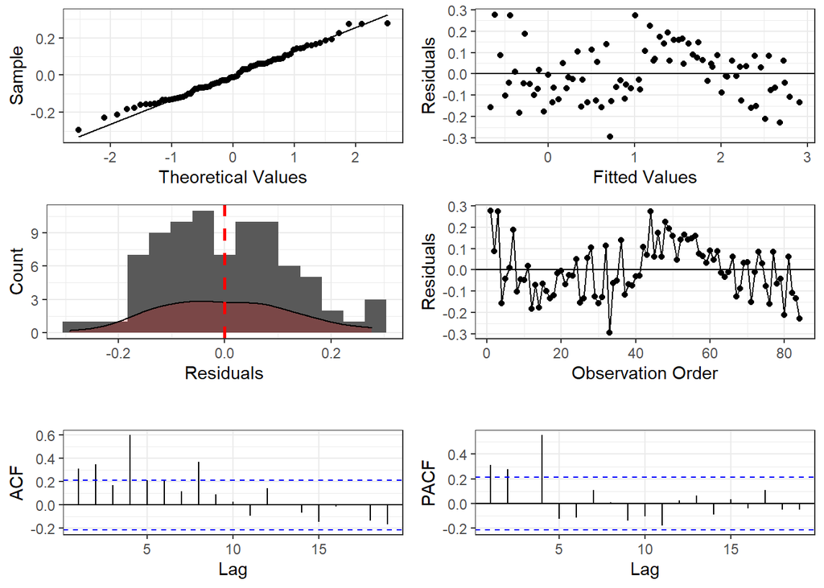

```r
resplot(res = model3$residuals, fit = model3$fitted.values)
```

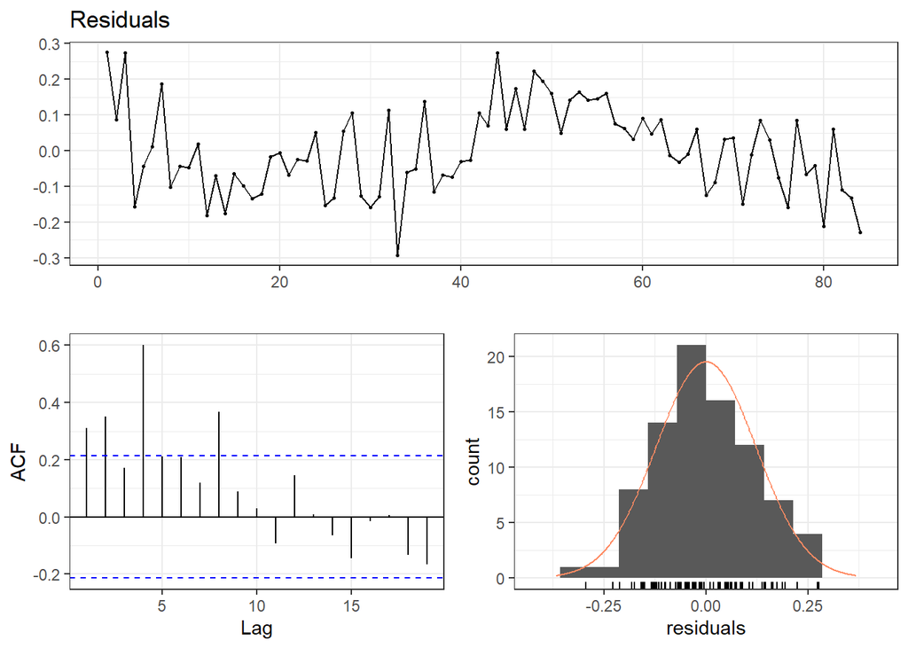

```
##
##  Breusch-Godfrey test for serial correlation of order up to 10
##
## data:  Residuals
## LM test = 41.168, df = 10, p-value = 1.054e-05
```

```r
checkresiduals(model3)
```

$$\begin{aligned}
y_t = -328.3 + 0.1672t & + 0.02812Q2 \\
& + 0.09823Q3 \\
& - 0.1705Q4
\end{aligned}$$

**Question: Based on the equation above, can we interpret the 0.02812 as the difference in predicted log EPS between Q1 and Q2?**

Using 1970Q1 to Q2 as an example,

Q1: $y_t = -328.3 + 0.1672*(1970.00) = 1.084$

Q2: $y_t = -328.3 + 0.1672*(1970.25) + (0.02812 * 1) = 1.15392$

Difference between the fitted values is 0.06992, which is equal to 0.1672*(0.25) + 0.02812.

## 2.2 Using the `tslm()` Function

```r
model4 = tslm(log_jj ~ trend + season)
summary(model4)
```

```
##
## Call:
## tslm(formula = log_jj ~ trend + season)
##
## Residuals:
##      Min       1Q   Median       3Q      Max
## -0.29318 -0.09062 -0.01180  0.08460  0.27644
##
## Coefficients:
##               Estimate Std. Error t value Pr(>|t|)
## (Intercept) -0.6607215  0.0358430 -18.434  < 2e-16 ***
## trend        0.0417930  0.0005648  73.999  < 2e-16 ***
## season2      0.0281227  0.0386959   0.727   0.4695
## season3      0.0982310  0.0387083   2.538   0.0131 *
## season4     -0.1705267  0.0387289  -4.403 3.31e-05 ***
## ---
## Signif. codes:  0 '***' 0.001 '**' 0.01 '*' 0.05 '.' 0.1 ' ' 1
##
## Residual standard error: 0.1254 on 79 degrees of freedom
## Multiple R-squared:  0.9859, Adjusted R-squared:  0.9852
## F-statistic:  1379 on 4 and 79 DF,  p-value: < 2.2e-16
```

# 3 Comparison with auto.arima() [In-Class Activity]

Use the log_jj data.

1. Use the `auto.arima()` function to fit an arima model to the data. What model is fit to the data?
2. Compare the residuals and the accuracy of the seasonal regression, to the auto.arima results. Which model fits better?

```r
model5 = auto.arima(log_jj)
summary(model5)
```

```
## Series: log_jj
## ARIMA(2,0,0)(1,1,0)[4] with drift
##
## Coefficients:
##          ar1     ar2     sar1   drift
##       0.2686  0.2855  -0.2695  0.0382
## s.e.  0.1137  0.1214   0.1212  0.0042
##
## sigma^2 estimated as 0.007793:  log likelihood=82.47
## AIC=-154.95   AICc=-154.14   BIC=-143.04
##
## Training set error measures:
##                       ME       RMSE        MAE MPE MAPE      MASE        ACF1
## Training set 0.002030151 0.08396647 0.06504478 NaN  Inf 0.4058742 -0.03591245
```

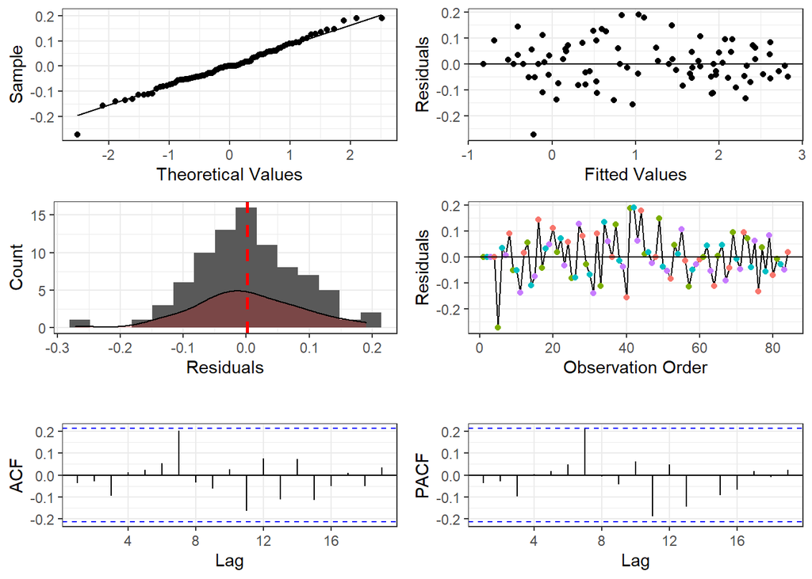

```r
resplot(res = model5$residuals, fit = model5$fitted, freq = 4)
```

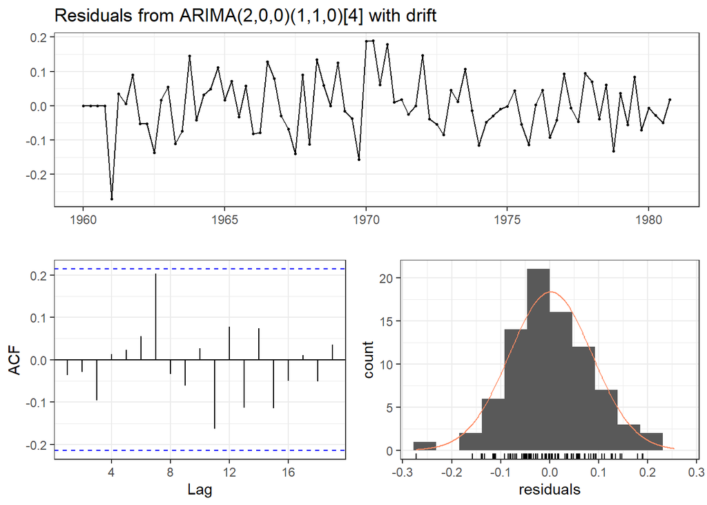

```
##
##  Ljung-Box test
##
## data:  Residuals from ARIMA(2,0,0)(1,1,0)[4] with drift
## Q* = 5.3331, df = 4, p-value = 0.2548
##
## Model df: 4.   Total lags used: 8
```

```r
checkresiduals(model5)
```

```r
AIC(model4)
```

```
## [1] -103.6153
```

```r
BIC(model4)
```

```
## [1] -89.03043
```

Based on: (a) AIC/BIC, (b) the models’ assumptions of iid residuals, and (c) the predictive accuracy of the models (as measured using RMSE), model5 from the ’auto.arima()` is a much better model.